# Clase x. Redes Neuronales II[^1]

Diego Kozlowski y Juan Barriola

# Convolutional Neural Networks

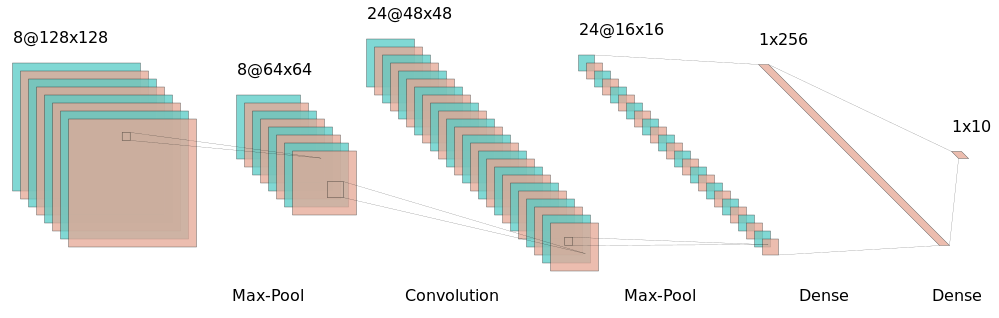

red convolucional

Vamos a utilizar la librería

#### [**KERAS**](https://keras.rstudio.com/)

```r
# devtools::install_github("rstudio/keras")
library(keras)
# install_keras()
library(tidyverse)
library(knitr)
```

## Mnist

Vamos a utilizar nuevamente el dataset de MNIST de la clase de *fully connected layers*

```r
mnist <- dataset_mnist()
x_train <- mnist$train$x
y_train <- mnist$train$y
x_test <- mnist$test$x
y_test <- mnist$test$y
```

Recordemos la pinta de los datos

**datos de entrada**

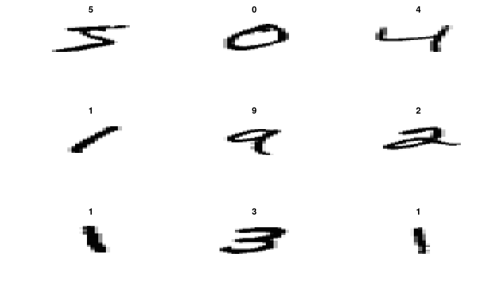

```r
matrix.rotate <- function(img) {
    t(apply(img, 2, rev))
}
par(mfrow=c(3, 3))
for (idx in 1:9) {
    label <- y_train[idx]
    image(matrix.rotate(x_train[idx,,]), col = grey(level = seq(1, 0, by=-1/255)), axes=F, main=label)

}
```

El dato esta en un array de 3 dimensiones (imagen,ancho,largo). Como tenemos 60K imágenes, esto tiene la forma de :

```r
dim(x_train)
```

```
[1] 60000    28    28
```

Dimensiones del problema:

Definamos como variables las siguientes dimensiones del problema (nos facilita la reutilización del código):

- número de clases
- largo de las imágenes
- ancho de las imágenes

```r
num_classes <- 10
img_rows <- 28
img_cols <- 28
```

### Data shape

En un problema normal de clasificación para Machine Learning tenemos 2 dimensiones: *filas y columnas*, donde la 1° representa las observaciones y la segunda la secuencia de features.

En el caso de las redes convolucionales necesitamos datos de 4 dimensiones:

1. observaciones
2. largo de la imagen(o matriz)
3. ancho de la imagen (o matriz)
4. dimensión del color: en imágenes normales a color: RGB, esta dimensión tiene extensión de 3, por los tres canales de color. En imágenes de blanco y negro, la dimensión es de extensión 1.

```r
x_train <- array_reshape(x_train, c(nrow(x_train), img_rows, img_cols, 1))
x_test <- array_reshape(x_test, c(nrow(x_test), img_rows, img_cols, 1))
input_shape <- c(img_rows, img_cols, 1)
```

- Además, necesitamos convertir la escala de los datos de íntegers entre 0 y 255 a números floating point entre 0 y 1

```r
x_train <- x_train / 255
x_test <- x_test / 255
```

```r
cat('x_train_shape:', dim(x_train), '\n')
```

```
x_train_shape: 60000 28 28 1
```

```r
cat(nrow(x_train), 'train samples\n')
```

```
60000 train samples
```

```r
cat(nrow(x_test), 'test samples\n')
```

```
10000 test samples
```

**datos de salida**

necesitamos pasarlo a **one-hot encoding** esto se hace con la función `to_categorical()` de Keras

```r
y_train <- to_categorical(y_train, num_classes)
y_test <- to_categorical(y_test, num_classes)
```

## Definción del modelo

Para armar el modelo primero definimos el tipo de modelo. Para eso usamos `keras_model_sequential()` que nos permite simplemente apilar capas de la red.

- En la primera capa tenemos que aclarar el input_shape.
- Las capas se agregan con pipes `%>%`
- La última capa tiene la misma cantidad de unidades que categorías nuestro output. La salida del modelo es un vector que asigna una probabilidad a cada una da las categorías
- En cada capa tenemos que definir una función de activación
- Además agregamos una regularización `layer_droput(x)` que lo que hace es, en cada iteración del ajuste, ignorar el x% de las conexiones. Esto evita el sobreajuste del modelo

```r
model <- keras_model_sequential() %>%
  layer_conv_2d(filters = 32, kernel_size = c(3,3), activation = 'relu',
                input_shape = input_shape) %>%
  layer_conv_2d(filters = 64, kernel_size = c(3,3), activation = 'relu') %>%
  layer_max_pooling_2d(pool_size = c(2, 2)) %>%
  layer_dropout(rate = 0.25) %>%
  layer_flatten() %>%
  layer_dense(units = 128, activation = 'relu') %>%
  layer_dropout(rate = 0.5) %>%
  layer_dense(units = num_classes, activation = 'softmax')
```

La arquitectura de esta red es básicamente la siguiente:

1. **Convolución**: 32 filtros (se achica la imagen original, y se multiplica en 32)
2. **Convolución**: 64 filtros (se vuelve a achicar y cada resultado del filtro se multiplica por 64)
3. **max_pooling**: Se achican las imágenes
4. **dropout**: se regulariza para evitar overfitting
5. **flatten**: Se aplanan los inputs para poder pasarlos a una red densa
6. **dense**: capa densa con 128 neuronas
7. **dropout**: se vuelve a regularizar
8. **dense** : capa de salida, con tantas neuronas como clases y una activación softmax (para que devuelva probabilidades)

### `layer_conv_2d`

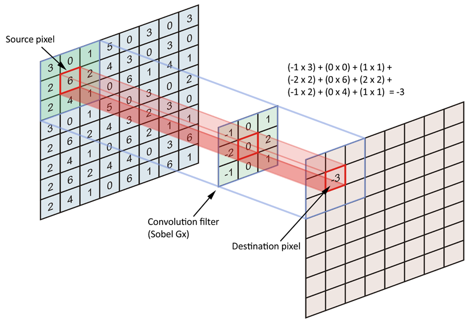

convolución[^2]

- La capa de convoluciones construye pequeños *filtros* o *kernels* de la dimensión `kernel_size()` que pasan por el input original realizando una *convolución*.
- El filtro *barre* la imagen original, moviéndose de a `strides()` posiciones. Por default se mueve de a 1 lugar.
- Notemos que si el filtro es de 3x3 y el stride es 1, entonces la imagen original va a perder 2 pixels de largo y 2 pixels de ancho.

### `layer_max_pooling_2d`

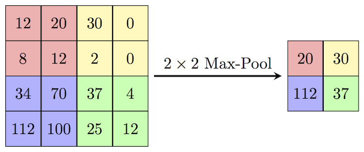

max pooling[^3]

- Es max pooling es una forma de reducir el tamaño de la matrix.
- Al igual que la convolución, *barre* la imagen con una ventana de `pool_size()` moviéndose de a `stride()` posiciones, y devuelve el valor más alto.
- Un `pool_size()` de 2x2 nos reduce el tamaño de la imagen a la mitad.

### `layer_dropout`

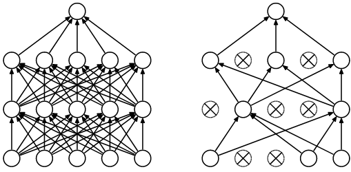

Dropout[^4]

- El dropout es un método de regularización donde para cada iteración del backpropagation, anula el ajuste para una `rate` proporción de los pesos. De esta forma, no se ajusta todo todo el tiempo, reduciendo los grados de libertad del modelo, y evitando el overfitting

### `layer_flatten`

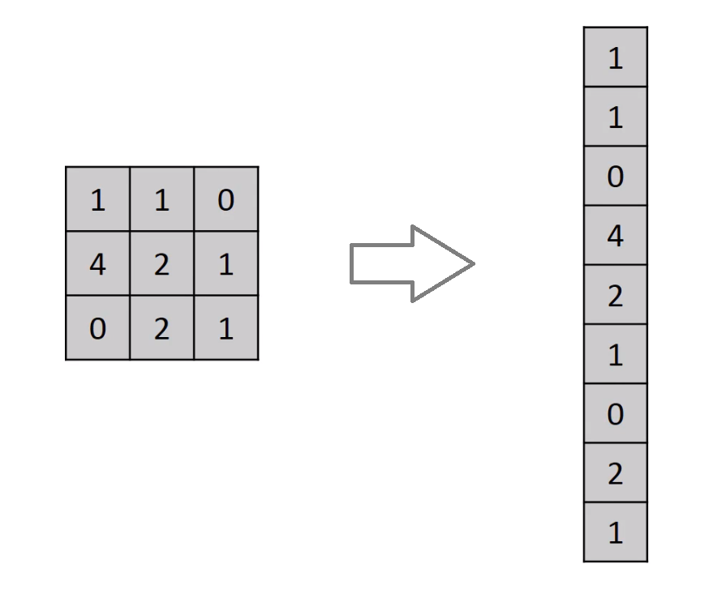

flatten[^5]

- Esta layer lo único que hace es un reshape para que los datos puedan ser utilizados por una capa densa.

### `layer_dense`

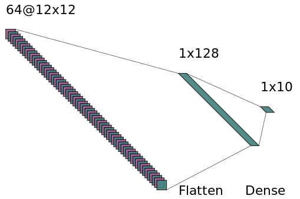

dense

- La capa densa es una *fully connected layer* que recibe como input el producto aplanado de las capas previas.

#### Funciones de activación

Para este modelo utilizamos las mismas dos funciones de activación que utilizamos en la FC nn:

- Rectified Linear Unit:
  $$f(x)=max(0,x)$$
- Softmax :
  $$f(x)=\frac{e^{x_i}}{\sum_{j=1}^n e^{x_j}}$$

Definidas en código y gráficamente:

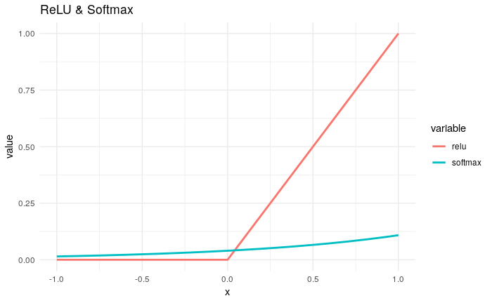

```r
relu <- function(x) ifelse(x >= 0, x, 0)
softmax <- function(x) exp(x) / sum(exp(x))
data.frame(x= seq(from=-1, to=1, by=0.1)) %>%
  mutate(softmax = softmax(x),
         relu = relu(x)) %>%
  gather(variable,value,2:3) %>%
ggplot(., aes(x=x, y=value, group=variable, colour=variable))+
  geom_line(size=1) +
  ggtitle("ReLU & Softmax")+
  theme_minimal()
```

**ReLu** es la función de activación que más se utiliza en la actualidad.

#### Parametros entrenables del modelo

```r
model
```

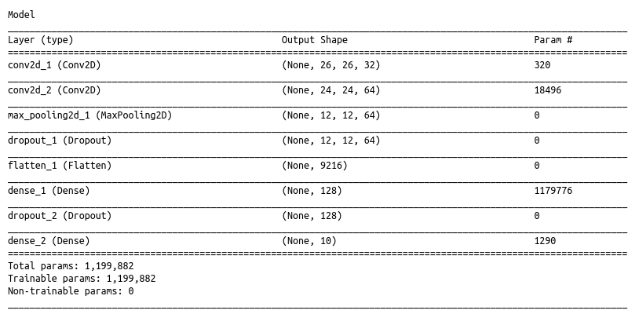

El modelo tiene 1.2 millones de parámetros para optimizar:

La primera capa convolucional tiene que entrenar los filtros. Como estos eran de 3x3, cada uno tiene 9 parámetros para entrenar + 1 bias por filtro

```r
32* (3*3) +32
```

```
[1] 320
```

La segunda convolución tiene que entrenar kernels de 3x3 para 64 filtros $64*(3*3)$, para cada uno de los 32 filtros de la capa anterior, +1 bias por filtro

```r
64*(3*3)*32 +64
```

```
[1] 18496
```

`layer_max_pooling_2d`, `layer_dropout` y `layer_flatten` no entrenan parámetros.

cuando aplanamos. El shape pasa a:

```r
12*12*64
```

```
[1] 9216
```

- La primera capa densa tienen que conectar 9216 nodos con los 128, más los 128 bias.
- La capa de salida tiene que conectar los 128 nodos con los 10 de salida, más 10 bias

```r
128*9216 +128
```

```
[1] 1179776
```

```r
128*10 +10
```

```
[1] 1290
```

Luego necesitamos **compilar el modelo** indicando la función de *loss*, qué tipo de optimizador utilizar, y qué métricas nos importan

```r
model <- model %>% compile(
  loss = "categorical_crossentropy",
  optimizer = optimizer_adadelta(),
  metrics = c('accuracy')
)
```

## Entrenamiento

Para ajustar el modelo usamos la función `fit()`, acá necesitamos pasar los siguientes parámetros:

- El array con los datos de entrenamiento
- El array con los outputs
- `epochs`: Cuantas veces va a recorrer el dataset de entrenamiento
- `batch_size`: de a cuantas imágenes va a mirar en cada iteración del backpropagation
- `validation_split`: Hacemos un split en train y validation para evaluar las métricas.

```r
epochs <- 12
batch_size <- 128
validation_split <- 0.2

fit_history <- model %>% fit(
  x_train, y_train,
  batch_size = batch_size,
  epochs = epochs,
  validation_split = validation_split
)
```

Mientras entrenamos el modelo, podemos ver la evolución en el gráfico interactivo que se genera en el viewer de Rstudio.

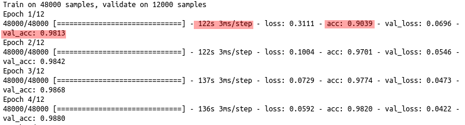

```r
fit_history
```

`fit()` nos devuelve un objeto que incluye las métricas de loss y accuracy.

Este objeto lo podemos graficar con `plot()` y nos devuelve un objeto de *ggplot*, sobre el que podemos seguir trabajando

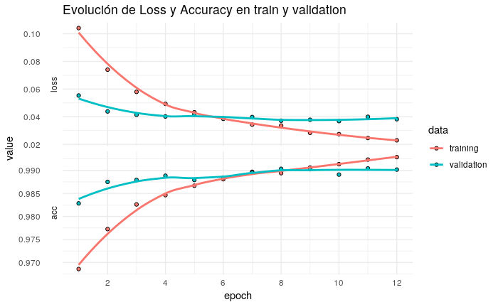

```r
plot(fit_history)+
  theme_minimal()+
  labs(title= "Evolución de Loss y Accuracy en train y validation")
```

**es importante guardar el modelo luego de entrenar, para poder reutilizarlo**

```r
model %>% save_model_hdf5("results/cnn_model.h5")
```

y para cargarlo

```r
modelo_preentrenado <- load_model_hdf5("results/cnn_model.h5")
```

```r
modelo_preentrenado
```

```
Model
__________________________________________________________________________________________________________________________
Layer (type)                                          Output Shape                                     Param #
==========================================================================================================================
conv2d_1 (Conv2D)                                     (None, 26, 26, 32)                               320
__________________________________________________________________________________________________________________________
conv2d_2 (Conv2D)                                     (None, 24, 24, 64)                               18496
__________________________________________________________________________________________________________________________
max_pooling2d_1 (MaxPooling2D)                        (None, 12, 12, 64)                               0
__________________________________________________________________________________________________________________________
dropout_3 (Dropout)                                   (None, 12, 12, 64)                               0
__________________________________________________________________________________________________________________________
flatten_1 (Flatten)                                   (None, 9216)                                     0
__________________________________________________________________________________________________________________________
dense_4 (Dense)                                       (None, 128)                                      1179776
__________________________________________________________________________________________________________________________
dropout_4 (Dropout)                                   (None, 128)                                      0
__________________________________________________________________________________________________________________________
dense_5 (Dense)                                       (None, 10)                                       1290
==========================================================================================================================
Total params: 1,199,882
Trainable params: 1,199,882
Non-trainable params: 0
__________________________________________________________________________________________________________________________
```

Si queremos evaluar el modelo sobre el conjunto de test (distinto del de validación) podemos usar la función `evaluate()`

```r
modelo_preentrenado %>% evaluate(x_test, y_test)
```

```
$loss
[1] 0.02666184

$acc
[1] 0.9925
```

Para obtener las predicciones sobre un nuevo conjunto de datos utilizamos `predict_classes()`

```r
modelo_preentrenado %>% predict_classes(x_test) %>% head(.)
```

```
[1] 7 2 1 0 4 1
```

Otros recursos interesantes:

[Visualización de una Red Fully conected para clasificación de dígitos](http://scs.ryerson.ca/~aharley/vis/conv/)

Tensor Flow Playground

[^1]: Estas notas estan basadas en https://tensorflow.rstudio.com/keras/#tutorials
[^2]: http://www.tbluche.com/files/MeetupSaoPaulo2017.pdf
[^3]: https://computersciencewiki.org/index.php/File:MaxpoolSample2.png
[^4]: http://jmlr.org/papers/volume15/srivastava14a.old/srivastava14a.pdf
[^5]: https://rubikscode.net/2018/02/26/introduction-to-convolutional-neural-networks/